# OC Clip Analysis

Import Pandas Library

```python
import pandas as pd
import seaborn as sns
import matplotlib.pyplot as plt
```

Raw Data Dalia worksheet

```python
pd.set_option('future.no_silent_downcasting', True)

raw_data = pd.read_csv(
    "C:/Users/dalia/OneDrive/CHARACTER TIME OC/Dalia Fixed Time Sheets.csv")


print(raw_data)
```

```
    Season  Episode Episode_length Character Start_time End_time  \
0        1        1        0:45:08      Ryan   12:45:08  0:37:20
1        1        1        0:45:08     Sandy    0:43:35  0:40:18
2        1        1        0:45:08     Sandy    0:38:41  0:36:22
3        1        1        0:45:08   Kirsten    0:37:20  0:36:22
4        1        1        0:45:08      Ryan    0:36:22  0:29:21
5        1        1        0:45:08   Marissa    0:36:22  0:33:51
6        1        1        0:45:08     Sandy    0:34:31  0:33:02
7        1        1        0:45:08      Luke    0:34:13  0:33:51
8        1        1        0:45:08   Kirsten    0:33:30  0:33:02
9        1        1        0:45:08      Seth    0:32:34  0:29:21
10       1        1        0:45:08     Sandy    0:31:55  0:31:44
11       1        1        0:45:08     Sandy    0:30:18  0:29:21
12       1        1        0:45:08   Marissa    0:29:38  0:28:12
13       1        1        0:45:08     Jimmy    0:28:47  0:28:12
```

[output cut: 106 more lines]

Clean Data from raw dataworksheet

```python
#to look at columns in my dfworking
raw_data.columns

#look at values in the character column
print(raw_data['Character'])


#to drop the NaN column in my dfworking, kept original and made new cleaned df, need axis = 1 to identify only column being removed
raw_data = raw_data.drop('Good_clip', axis = 1)

#to check the new columns in new df
raw_data.columns

print(raw_data)
```

```
0        Ryan
1       Sandy
2       Sandy
3     Kirsten
4        Ryan
5     Marissa
6       Sandy
7        Luke
8     Kirsten
9        Seth
10      Sandy
11      Sandy
12    Marissa
13      Jimmy
14       Ryan
```

[output cut: 166 more lines]

To create datasets for each character

```python
# Create empty
character_seconds_df = pd.DataFrame(columns=["Character", "Seconds"])

# Create list of characters
char_list = raw_data['Character'].unique()

n=0
for char in char_list:
    temp_char_df = raw_data[raw_data["Character"] == char]

    temp_char_total = sum(temp_char_df['Clip_length'])

    # Fill in dataframe with character totals
    character_seconds_df.loc[n,"Character"] = char
    character_seconds_df.loc[n,"Seconds"] = temp_char_total
    n += 1

print(character_seconds_df)
```

```
  Character Seconds
0      Ryan    2193
1     Sandy     834
2   Kirsten     328
3   Marissa     670
4      Luke     151
5      Seth     915
6     Jimmy     176
7     Julie      39
8    Summer     332
```

Make a Screentime Dataset for all Characters and their time on screen

```python
ftr = [3600,60,1]

test = raw_data['Episode_length'][0]
print(test)

total_epleng = sum([a*b for a,b in zip(ftr, map(int,test.split(':')))])

screentime_data = pd.DataFrame(columns = char_list, index = range(total_epleng))

for n_row in raw_data.index:
    temp_char = raw_data.loc[n_row,'Character']
    temp_start_idx= raw_data.loc[n_row, 'Start_second']
    temp_end_idx = raw_data.loc[n_row, 'End_second']
    screentime_data.loc[temp_start_idx:temp_end_idx, temp_char] = 1

screentime_data.fillna(0, inplace = True)

print(screentime_data)
```

```
0:45:08
     Ryan Sandy Kirsten Marissa Luke Seth Jimmy Julie Summer
0       1     0       0       0    0    0     0     0      0
1       1     0       0       0    0    0     0     0      0
2       1     0       0       0    0    0     0     0      0
3       1     0       0       0    0    0     0     0      0
4       1     0       0       0    0    0     0     0      0
...   ...   ...     ...     ...  ...  ...   ...   ...    ...
2703    0     0       0       0    0    0     0     0      0
2704    0     0       0       0    0    0     0     0      0
2705    0     0       0       0    0    0     0     0      0
2706    0     0       0       0    0    0     0     0      0
2707    0     0       0       0    0    0     0     0      0

[2708 rows x 9 columns]
```

```
Figure(640x480)
```

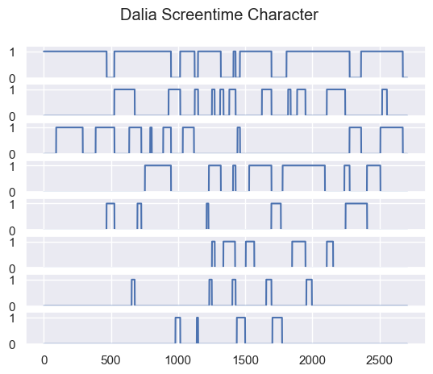

```python
fig, axs = plt.subplots(8, sharex=True, sharey=True)
fig.suptitle('Dalia Screentime Character')
axs[0].plot(screentime_data['Ryan'])
axs[1].set_ylim(0, 1.2)
axs[2].plot(screentime_data['Sandy'])
axs[2].set_ylim(0, 1.2)
axs[3].plot(screentime_data['Seth'])
axs[3].set_ylim(0, 1.2)
axs[4].plot(screentime_data['Kirsten'])
axs[4].set_ylim(0, 1.2)
axs[5].plot(screentime_data['Summer'])
axs[5].set_ylim(0, 1.2)
axs[0].set_ylim(0, 1.2)
axs[1].plot(screentime_data['Marissa'])
axs[6].plot(screentime_data['Luke'])
axs[6].set_ylim(0, 1.2)
axs[7].plot(screentime_data['Jimmy'])
axs[7].set_ylim(0, 1.2)

print(fig)
```

Upload Sophia and Zach rawdatasets to work on

```python
zach_data = pd.read_csv("C:/Users/dalia/OneDrive/CHARACTER TIME OC/ZACH- character_time_stamps.csv")

print(zach_data)

sophia_data = pd.read_csv("C:/Users/dalia/OneDrive/CHARACTER TIME OC/SOPHIA -character_time_stamps.csv")

print(sophia_data)

#made a copy of my original raw dataset for manipulation
dalia_data = raw_data.copy()

print(dalia_data)
```

```
     Season  Episode Episode_length Character Start_time End_time  \
0       1.0      1.0        0:45:08      Ryan    0:45:08  0:29:42
1       1.0      1.0        0:45:08     Sandy    0:43:41  0:40:27
2       1.0      1.0        0:45:08     Sandy    0:38:48  0:36:27
3       1.0      1.0        0:45:08   Kirsten    0:37:28  0:36:27
4       1.0      1.0        0:45:08  Marissa     0:36:24  0:33:54
..      ...      ...            ...       ...        ...      ...
994     NaN      NaN            NaN       NaN        NaN      NaN
995     NaN      NaN            NaN       NaN        NaN      NaN
996     NaN      NaN            NaN       NaN        NaN      NaN
997     NaN      NaN            NaN       NaN        NaN      NaN
998     NaN      NaN            NaN       NaN        NaN      NaN

     Start_second  End_second  Clip_length Good_clip
0             0.0       926.0        926.0       NaN
```

[output cut: 160 more lines]

Fixing raw data from sophia and zach datasets

```python
sophia_data = sophia_data.drop('Good_clip', axis =1)

sophia_data.drop(sophia_data.index[81:], inplace=True)

sophia_data.loc[74:80] = sophia_data.loc[74:80].fillna({'Season':1})

print(sophia_data)

#zach data fixing
zach_data = zach_data.drop(63)

zach_data.drop(zach_data.index[154:], inplace = True)

zach_data = zach_data.drop('Good_clip', axis = 1)

zach_data = zach_data.replace(to_replace="Marissa ", value="Marissa")

print(zach_data)
```

```
    Season  Episode Episode_length Character Start_time End_time  \
0      1.0      1.0        0:45:08      Ryan    0:45:08  0:33:02
1      1.0      1.0        0:45:08     Sandy    0:43:42  0:40:29
2      1.0      1.0        0:45:08     Sandy    0:38:47  0:36:28
3      1.0      1.0        0:45:08   Kirsten    0:37:36  0:36:28
4      1.0      1.0        0:45:08   Marissa    0:36:20  0:33:54
..     ...      ...            ...       ...        ...      ...
76     1.0      2.0        0:45:08   Kirsten    0:42:46  0:41:55
77     1.0      2.0        0:45:08      Seth    0:41:54  0:39:01
78     1.0      2.0        0:45:08      Ryan    0:41:54  0:39:01
79     1.0      2.0        0:45:08     Sandy    0:41:27  0:39:01
80     1.0      2.0        0:45:08   Kirsten    0:41:27  0:39:01

    Start_second  End_second  Clip_length
0            0.0       726.0        726.0
```

[output cut: 39 more lines]

Add a source column to all datasets

```python
dalia_data['Source'] = 'Dalia'
zach_data['Source'] = 'Zach'
sophia_data['Source'] = 'Sophia'

print(zach_data)
print(sophia_data)
print(dalia_data)
```

```
     Season  Episode Episode_length Character Start_time End_time  \
0       1.0      1.0        0:45:08      Ryan    0:45:08  0:29:42
1       1.0      1.0        0:45:08     Sandy    0:43:41  0:40:27
2       1.0      1.0        0:45:08     Sandy    0:38:48  0:36:27
3       1.0      1.0        0:45:08   Kirsten    0:37:28  0:36:27
4       1.0      1.0        0:45:08   Marissa    0:36:24  0:33:54
..      ...      ...            ...       ...        ...      ...
150     1.0      2.0        0:43:46     Julie    0:26:11  0:25:50
151     1.0      2.0        0:43:46     Julie    0:25:25  0:24:31
152     1.0      2.0        0:43:46     Julie    0:21:05  0:20:40
153     1.0      2.0        0:43:46     Julie    0:07:10  0:05:56
154     1.0      2.0        0:43:46     Julie    0:02:18  0:00:37

     Start_second  End_second  Clip_length Source
0             0.0       926.0        926.0   Zach
```

[output cut: 160 more lines]

Merge Datasets

```python
mergedf = pd.merge(dalia_data, zach_data, how='outer')

print(mergedf)
masterdf = pd.merge(mergedf, sophia_data, how = 'outer')
print(masterdf)
```

```
     Season  Episode Episode_length Character Start_time End_time  \
0       1.0      1.0        0:45:08     Jimmy    0:16:45  0:15:34
1       1.0      1.0        0:45:08     Jimmy    0:16:51  0:15:36
2       1.0      1.0        0:45:08     Jimmy    0:21:10  0:20:09
3       1.0      1.0        0:45:08     Jimmy    0:21:47  0:20:14
4       1.0      1.0        0:45:08     Jimmy    0:26:08  0:25:59
..      ...      ...            ...       ...        ...      ...
208     1.0      2.0        0:43:46      Seth    0:41:55  0:39:00
209     1.0      2.0        0:43:46      Seth    0:42:56  0:42:47
210     1.0      2.0        0:43:46    Summer    0:04:57  0:04:42
211     1.0      2.0        0:43:46    Summer    0:13:55  0:12:50
212     1.0      2.0        0:43:46    Summer    0:28:11  0:27:52

     Start_second  End_second  Clip_length Source
0          1703.0      1774.0         71.0  Dalia
```

[output cut: 39 more lines]

# Create a new dataset to examine episode 1 data in a barplot

```
     Season  Episode Episode_length Character Start_time End_time  \
0       1.0      1.0        0:45:08     Jimmy    0:16:45  0:15:34
1       1.0      1.0        0:45:08     Jimmy    0:16:51  0:15:36
2       1.0      1.0        0:45:08     Jimmy    0:16:52  0:15:35
3       1.0      1.0        0:45:08     Jimmy    0:21:10  0:20:09
4       1.0      1.0        0:45:08     Jimmy    0:21:22  0:20:16
..      ...      ...            ...       ...        ...      ...
190     1.0      1.0        0:45:08    Summer    0:22:55  0:22:32
191     1.0      1.0        0:45:08    Summer    0:22:56  0:20:49
192     1.0      1.0        0:45:08    Summer    0:24:15  0:23:55
193     1.0      1.0        0:45:08    Summer    0:24:16  0:23:46
194     1.0      1.0        0:45:08    Summer    0:24:16  0:23:58

     Start_second  End_second  Clip_length  Source
0          1703.0      1774.0         71.0   Dalia
```

[output cut: 156 more lines]

[figure not shown]

```python
# make new df for episode 1 bar plot

ep_1_df = masterdf[masterdf['Episode']  <2]

print(ep_1_df)

character_seconds_source_df = pd.DataFrame(columns=["Character", "Seconds","Source"])

print(character_seconds_source_df)

# Create list of characters
char_list2 = ep_1_df.drop_duplicates(subset=['Character', 'Source'])

print(char_list2)

char_list3 = char_list2[['Character','Source']]

print(char_list3)

n=0
source_list = ep_1_df['Source'].unique()
for char in char_list:
    temp_char_df = ep_1_df[ep_1_df["Character"] == char]
    for rater in source_list:
        temp_char_source = temp_char_df[temp_char_df['Source'] == rater]
        temp_char_total = sum(temp_char_source['Clip_length'])

        # Fill in dataframe with character totals
        character_seconds_source_df.loc[n,"Character"] = char
        character_seconds_source_df.loc[n,"Seconds"] = temp_char_total
        character_seconds_source_df.loc[n,'Source'] = rater
        n += 1

print(character_seconds_source_df)

source_ep1_bar = character_seconds_source_df.sort_values(by = 'Seconds', ascending = False)
#df_bar3 = plt.bar(df_bar2['Character'],df_bar2['Seconds'], group = df_bar2['Source'])

print(source_ep1_bar)

sns.barplot(data = source_ep1_bar, x='Character', y='Seconds', hue='Source')
```

Zach Individual Dataset and Lineplot

```
0:45:08
['Ryan' 'Sandy' 'Kirsten' 'Marissa' 'Luke' 'Seth' 'Jimmy' 'Julie' 'Summer']
     Ryan Sandy Kirsten Marissa Luke Seth Jimmy Julie Summer
0     NaN   NaN     NaN     NaN  NaN  NaN   NaN   NaN    NaN
1     NaN   NaN     NaN     NaN  NaN  NaN   NaN   NaN    NaN
2     NaN   NaN     NaN     NaN  NaN  NaN   NaN   NaN    NaN
3     NaN   NaN     NaN     NaN  NaN  NaN   NaN   NaN    NaN
4     NaN   NaN     NaN     NaN  NaN  NaN   NaN   NaN    NaN
...   ...   ...     ...     ...  ...  ...   ...   ...    ...
2703  NaN   NaN     NaN     NaN  NaN  NaN   NaN   NaN    NaN
2704  NaN   NaN     NaN     NaN  NaN  NaN   NaN   NaN    NaN
2705  NaN   NaN     NaN     NaN  NaN  NaN   NaN   NaN    NaN
2706  NaN   NaN     NaN     NaN  NaN  NaN   NaN   NaN    NaN
2707  NaN   NaN     NaN     NaN  NaN  NaN   NaN   NaN    NaN

```

[output cut: 16 more lines]

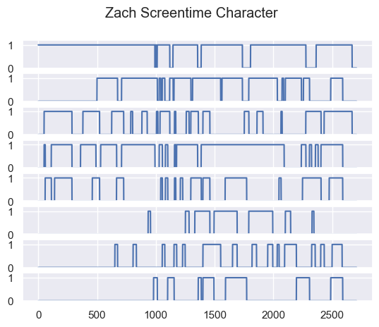

```python
ftr = [3600,60,1]

test = zach_data['Episode_length'][0]
print(test)

zchar = zach_data['Character'].unique()

print(zchar)

z_total_epleng = sum([a*b for a,b in zip(ftr, map(int,test.split(':')))])

zach_data_screentime = pd.DataFrame(columns = zchar, index = range(z_total_epleng))

print(zach_data_screentime)

for n_row in zach_data.index:
    temp_char = zach_data.loc[n_row,'Character']
    temp_start_idx= zach_data.loc[n_row, 'Start_second']
    temp_end_idx = zach_data.loc[n_row, 'End_second']
    zach_data_screentime.loc[temp_start_idx:temp_end_idx, temp_char] = 1

zach_data_screentime.fillna(0, inplace = True)

print(zach_data_screentime)


#zach lineplot

fig, axs = plt.subplots(8, sharex=True, sharey=True)
fig.suptitle('Zach Screentime Character')
axs[0].plot(zach_data_screentime['Ryan'])
axs[1].set_ylim(0, 1.2)
axs[2].plot(zach_data_screentime['Sandy'])
axs[2].set_ylim(0, 1.2)
axs[3].plot(zach_data_screentime['Seth'])
axs[3].set_ylim(0, 1.2)
axs[4].plot(zach_data_screentime['Kirsten'])
axs[4].set_ylim(0, 1.2)
axs[5].plot(zach_data_screentime['Summer'])
axs[5].set_ylim(0, 1.2)
axs[0].set_ylim(0, 1.2)
axs[1].plot(zach_data_screentime['Marissa'])
axs[6].plot(zach_data_screentime['Luke'])
axs[6].set_ylim(0, 1.2)
axs[7].plot(zach_data_screentime['Jimmy'])
axs[7].set_ylim(0, 1.2)

print(fig)
```

Sophia Individual Dataset and Lineplot

```
0:45:08
['Ryan' 'Sandy' 'Kirsten' 'Marissa' 'Luke' 'Seth' 'Jimmy' 'Julie' 'Summer']
     Ryan Sandy Kirsten Marissa Luke Seth Jimmy Julie Summer
0     NaN   NaN     NaN     NaN  NaN  NaN   NaN   NaN    NaN
1     NaN   NaN     NaN     NaN  NaN  NaN   NaN   NaN    NaN
2     NaN   NaN     NaN     NaN  NaN  NaN   NaN   NaN    NaN
3     NaN   NaN     NaN     NaN  NaN  NaN   NaN   NaN    NaN
4     NaN   NaN     NaN     NaN  NaN  NaN   NaN   NaN    NaN
...   ...   ...     ...     ...  ...  ...   ...   ...    ...
2703  NaN   NaN     NaN     NaN  NaN  NaN   NaN   NaN    NaN
2704  NaN   NaN     NaN     NaN  NaN  NaN   NaN   NaN    NaN
2705  NaN   NaN     NaN     NaN  NaN  NaN   NaN   NaN    NaN
2706  NaN   NaN     NaN     NaN  NaN  NaN   NaN   NaN    NaN
2707  NaN   NaN     NaN     NaN  NaN  NaN   NaN   NaN    NaN

```

[output cut: 16 more lines]

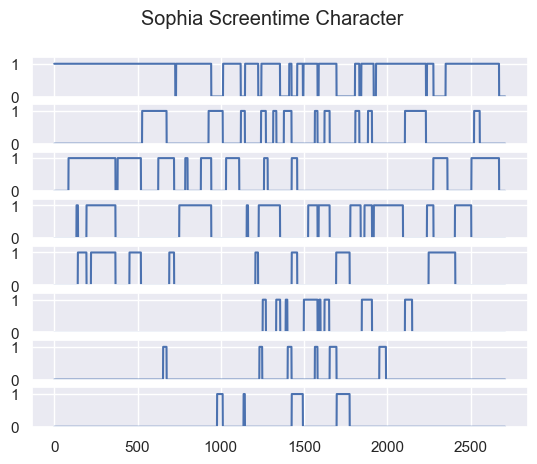

```python
ftr = [3600,60,1]

test = sophia_data['Episode_length'][0]
print(test)

schar = sophia_data['Character'].unique()

print(schar)

s_total_epleng = sum([a*b for a,b in zip(ftr, map(int,test.split(':')))])

sophia_data_screentime = pd.DataFrame(columns = schar, index = range(s_total_epleng))

print(sophia_data_screentime)

for n_row in sophia_data.index:
    temp_char = sophia_data.loc[n_row,'Character']
    temp_start_idx= sophia_data.loc[n_row, 'Start_second']
    temp_end_idx = sophia_data.loc[n_row, 'End_second']
    sophia_data_screentime.loc[temp_start_idx:temp_end_idx, temp_char] = 1

sophia_data_screentime.fillna(0, inplace = True)

print(sophia_data_screentime)

#Sophia Lineplot

fig, axs = plt.subplots(8, sharex=True, sharey=True)
fig.suptitle('Sophia Screentime Character')
axs[0].plot(sophia_data_screentime['Ryan'])
axs[1].set_ylim(0, 1.2)
axs[2].plot(sophia_data_screentime['Sandy'])
axs[2].set_ylim(0, 1.2)
axs[3].plot(sophia_data_screentime['Seth'])
axs[3].set_ylim(0, 1.2)
axs[4].plot(sophia_data_screentime['Kirsten'])
axs[4].set_ylim(0, 1.2)
axs[5].plot(sophia_data_screentime['Summer'])
axs[5].set_ylim(0, 1.2)
axs[0].set_ylim(0, 1.2)
axs[1].plot(sophia_data_screentime['Marissa'])
axs[6].plot(sophia_data_screentime['Luke'])
axs[6].set_ylim(0, 1.2)
axs[7].plot(sophia_data_screentime['Jimmy'])
axs[7].set_ylim(0, 1.2)

print(fig)
```

Make combined dataset for screentime analysis

```python
sophia_data_screentime['Rater'] = 'Sophia'

zach_data_screentime['Rater'] = 'Zach'

screentime_data['Rater'] = 'Dalia'

screentime_data['Seconds'] = screentime_data.index

sophia_data_screentime['Seconds'] = sophia_data_screentime.index

zach_data_screentime['Seconds'] = zach_data_screentime.index

print(sophia_data_screentime)
print(zach_data_screentime)
print(screentime_data)


zach_sophia_data_screentime = pd.merge(sophia_data_screentime, zach_data_screentime, how='outer')

print(zach_sophia_data_screentime)

screentime_sum = pd.merge(zach_sophia_data_screentime, screentime_data, how = 'outer')

print(screentime_sum)
```

```
     Ryan Sandy Kirsten Marissa Luke Seth Jimmy Julie Summer   Rater  Seconds
0       1     0       0       0    0    0     0     0      0  Sophia        0
1       1     0       0       0    0    0     0     0      0  Sophia        1
2       1     0       0       0    0    0     0     0      0  Sophia        2
3       1     0       0       0    0    0     0     0      0  Sophia        3
4       1     0       0       0    0    0     0     0      0  Sophia        4
...   ...   ...     ...     ...  ...  ...   ...   ...    ...     ...      ...
2703    0     0       0       0    0    0     0     0      0  Sophia     2703
2704    0     0       0       0    0    0     0     0      0  Sophia     2704
2705    0     0       0       0    0    0     0     0      0  Sophia     2705
2706    0     0       0       0    0    0     0     0      0  Sophia     2706
2707    0     0       0       0    0    0     0     0      0  Sophia     2707

[2708 rows x 11 columns]
     Ryan Sandy Kirsten Marissa Luke Seth Jimmy Julie Summer Rater  Seconds
```

[output cut: 55 more lines]

# Graph for screentime plot with all three raters

```
Figure(640x480)
0       1
1       1
2       1
3       1
4       1
       ..
2703    0
2704    0
2705    0
2706    0
2707    0
Name: Ryan, Length: 2708, dtype: object
0       1
1       1
2       1
3       1
4       1
       ..
2703    0
2704    0
2705    0
2706    0
2707    0
Name: Ryan, Length: 2708, dtype: object
2708 2708
```

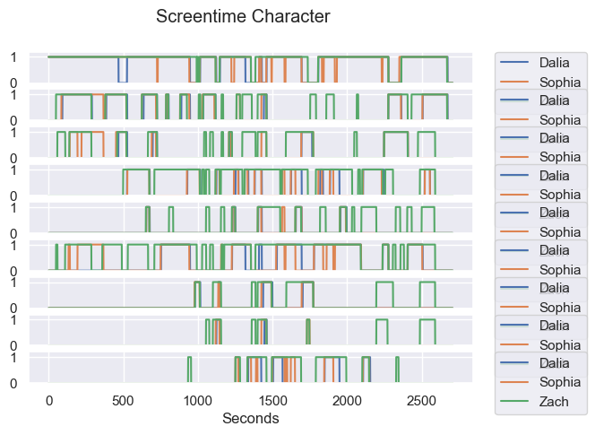

```python
from matplotlib import pyplot as plt
sns.set()



fig, axs = plt.subplots(9, sharex=True, sharey=True)
fig.suptitle('Screentime Character')
n=0
for char in char_list:
    sns.lineplot(data = screentime_sum, x= screentime_sum['Seconds'], y=screentime_sum[char].values, hue = 'Rater', ax = axs[n])
    plt.ylim(0, 1.2)
    axs[n].legend(loc='upper left', bbox_to_anchor=(1.05, 1), borderaxespad=0.)
    n=n+1
print(fig)



# Interrater between Sophia and Zach

from sklearn.metrics import cohen_kappa_score

ryan_zach = zach_data_screentime['Ryan']
ryan_sophia = sophia_data_screentime['Ryan']

print(ryan_zach)

print(ryan_sophia)

print(len(ryan_zach), len(ryan_sophia))

#KEEP GETTING AN ERROR AT THE BELOW CODE NEED TO FIGURE OUT
#ryan_zach_sophia_score = cohen_kappa_score(ryan_zach, ryan_sophia)


#print(ryan_zach_sophia_score)
```

```python
from sklearn.metrics import cohen_kappa_score

kappa_results = pd.DataFrame(columns = char_list)

kappa_results['Raters'] = 'Zach and Sophia','Dalia and Sophia','Zach and Dalia'

for char in char_list:
    temp_rater_list_zach = zach_data_screentime[char]
    temp_rater_list_sophia = sophia_data_screentime[char]
    temp_rater_list_dalia = screentime_data[char]

#    temp_output1 = cohen_kappa_score(temp_rater_list_zach, temp_rater_list_sophia)
#    temp_output2 = cohen_kappa_score(temp_rater_list_dalia, temp_rater_list_sophia)
#    temp_output3 = cohen_kappa_score(temp_rater_list_zach, temp_rater_list_dalia)


#    kappa_results.loc[kappa_results['Raters'] == 'Zach and Sophia', char] = temp_output1
#    kappa_results.loc[kappa_results['Raters'] == 'Dalia and Sophia', char] = temp_output2
#    kappa_results.loc[kappa_results['Raters'] == 'Zach and Dalia', char] = temp_output3

#print(kappa_results)
```

- 1st, make previous screentime datasets for each only filtered only for Episode 1

```python
#For Zach
zach_data_ep1 = zach_data[zach_data['Episode'] == 1]

ftr = [3600,60,1]

test = zach_data_ep1['Episode_length'][0]
print(test)

zchar = zach_data_ep1['Character'].unique()

z_total_epleng = sum([a*b for a,b in zip(ftr, map(int,test.split(':')))])

zach_screentime_ep1 = pd.DataFrame(columns = zchar, index = range(z_total_epleng))

for n_row in zach_data_ep1.index:
    temp_char = zach_data_ep1.loc[n_row,'Character']
    temp_start_idx= zach_data_ep1.loc[n_row, 'Start_second']
    temp_end_idx = zach_data_ep1.loc[n_row, 'End_second']
    zach_screentime_ep1.loc[temp_start_idx:temp_end_idx, temp_char] = 1

zach_screentime_ep1.fillna(0, inplace = True)

#For Sophia
sophia_data_ep1 = sophia_data[sophia_data['Episode'] == 1]

ftr = [3600,60,1]

test = sophia_data_ep1['Episode_length'][0]
print(test)

schar = sophia_data_ep1['Character'].unique()

s_total_epleng = sum([a*b for a,b in zip(ftr, map(int,test.split(':')))])

sophia_screentime_ep1 = pd.DataFrame(columns = schar, index = range(s_total_epleng))

for n_row in sophia_data_ep1.index:
    temp_char = sophia_data_ep1.loc[n_row,'Character']
    temp_start_idx= sophia_data_ep1.loc[n_row, 'Start_second']
    temp_end_idx = sophia_data_ep1.loc[n_row, 'End_second']
    sophia_screentime_ep1.loc[temp_start_idx:temp_end_idx, temp_char] = 1

sophia_screentime_ep1.fillna(0, inplace = True)

#fixing an error sign
pd.set_option('future.no_silent_downcasting', True)


char_list = raw_data['Character'].unique()
```

```
0:45:08
0:45:08
```

kappa_results_ep1 = pd.DataFrame(columns = char_list)

kappa_results_ep1['Raters'] = 'Zach and Sophia','Dalia and Sophia','Zach and Dalia'

```
temp_output1 = cohen_kappa_score(temp_rater_list_zach, temp_rater_list_sophia)
temp_output2 = cohen_kappa_score(temp_rater_list_dalia, temp_rater_list_sophia)
temp_output3 = cohen_kappa_score(temp_rater_list_zach, temp_rater_list_dalia)


kappa_results_ep1.loc[kappa_results_ep1['Raters'] == 'Zach and Sophia', char] = temp_output1
kappa_results_ep1.loc[kappa_results_ep1['Raters'] == 'Dalia and Sophia', char] = temp_output2
kappa_results_ep1.loc[kappa_results_ep1['Raters'] == 'Zach and Dalia', char] = temp_output3
```

print(kappa_results_ep1)

kappa_results_long = kappa_results_ep1.melt(id_vars="Raters", var_name="Character", value_name="Kappa Score")

print(kappa_results_bar)

Make a relationship dictionary of screentime for characters

```python
zach_screentime_ep1['Seconds'] = zach_data_screentime.index
print(zach_screentime_ep1)

#this is an example of what I was trying to do that I attempted
temp_seth_ryan_z = zach_screentime_ep1[(zach_screentime_ep1['Ryan'] == 1)
                                       & (zach_screentime_ep1['Seth'] == 1 )]
grouped = temp_seth_ryan_z.groupby('Seth').sum()


#to chunk my lists by successive, I used this
#new definition chunk_by_successiev for my lists
def chunk_by_successive(lst):
        """Chunks a list of numbers based on successive sequences."""

        result = []
        current_chunk = []

        for num in lst:
            if not current_chunk or num == current_chunk[-1] + 1:
                current_chunk.append(num)
            else:
                result.append(current_chunk)
                current_chunk = [num]

        if current_chunk:
            result.append(current_chunk)

        return result

#example of this
seth_ryan = chunk_by_successive(temp_seth_ryan_z['Seconds'])
print(seth_ryan)



# Generate all unique combinations of pairs
import itertools
char_pairings = list(itertools.combinations(char_list, 2))

print(char_list)




# make a new list with zach and sphia agreement data on
#when characters are on screen (time wise)




#first attempt was as a df not a list, was not successful, was not getting successive
# Add the shared values to a new column in df

ryan_df = pd.DataFrame()
print(ryan_df)

for char in char_list:
    temp_df_zach = zach_screentime_ep1[zach_screentime_ep1[char] == 1
                                       & zach_screentime_ep1['Seconds']]
    print(temp_df_zach)
    temp_df_sophia = sophia_screentime_ep1[sophia_screentime_ep1[char] == 1
                                           & sophia_screentime_ep1['Seconds']]
    print(temp_df_sophia)
    zach_sophia_ep1 = pd.merge(temp_df_zach, temp_df_sophia, how = 'inner')
    print(zach_sophia_ep1)


#here is the actual successive chunking. Got it to work till the end.
#Need to trouble shoot the last 4 lines starting from n=0


temp_shared_list = []
for char_a in char_list:
    for char_b in char_list:
        if char_a != char_b:
            temp_df_zach = zach_screentime_ep1[(zach_screentime_ep1[char_a] == 1) &
                                (zach_screentime_ep1[char_b] == 1)][['Seconds',char_a, char_b]]
            print(temp_df_zach)
for char_a in char_list:
    for char_b in char_list:
        if char_a != char_b:
            temp_df_sophia = sophia_screentime_ep1[(sophia_screentime_ep1[char_a] == 1) &
                                                   (sophia_screentime_ep1[char_b] == 1)][['Seconds', char_a, char_b]]
            print(temp_df_sophia)
#Above code gives me a temp df from sophia and
#zach of the character pairings and their corredponding seconds
            temp_zach_list = temp_df_zach['Seconds']
            print(temp_zach_list)
            temp_list_sophia = temp_df_sophia['Seconds']
            print(temp_list_sophia)
            for x in temp_zach_list:
                if x in temp_list_sophia:
                    temp_shared_list.append(x)
                    print(temp_shared_list)
                    chunked_list = chunk_by_successive(temp_shared_list)
                    print(chunked_list)







#   I think at this point, where I have the 1 to 1 get
#            temp_zach_list = temp_df_zach['Seconds']
#            print(temp_zach_list)
#            temp_list_sophia = temp_df_sophia['Seconds']
#            print(temp_list_sophia)
#            for x in temp_zach_list:
#                if x in temp_list_sophia:
#                   temp_shared_list.append(x)
#                   chunked_list = chunk_by_successive(temp_shared_list)
#                   for sublist in chunked_list:
#                       for n in range(len(sublist)):
#                           chunked_list.append([sublist[n], sublist[-1]])
```

```
     Ryan Sandy Kirsten Marissa Luke Seth Jimmy Julie Summer  Seconds
0       1     0       0       0    0    0     0     0      0        0
1       1     0       0       0    0    0     0     0      0        1
2       1     0       0       0    0    0     0     0      0        2
3       1     0       0       0    0    0     0     0      0        3
4       1     0       0       0    0    0     0     0      0        4
...   ...   ...     ...     ...  ...  ...   ...   ...    ...      ...
2703    0     0       0       0    0    0     0     0      0     2703
2704    0     0       0       0    0    0     0     0      0     2704
2705    0     0       0       0    0    0     0     0      0     2705
2706    0     0       0       0    0    0     0     0      0     2706
2707    0     0       0       0    0    0     0     0      0     2707

[2708 rows x 10 columns]
[[752, 753, 754, 755, 756, 757, 758, 759, 760, 761, 762, 763, 764, 765, 766, 767, 768, 769, 770, 771, 772, 773, 774, 775, 776, 777, 778, 779, 780, 781, 782, 783, 784, 785, 786, 787, 788, 789, 790, 791, 792, 793, 794, 795, 796, 797, 798, 799, 800, 801, 802, 803, 804, 805, 806, 807, 808, 809, 810, 811…
['Ryan' 'Sandy' 'Kirsten' 'Marissa' 'Luke' 'Seth' 'Jimmy' 'Julie' 'Summer']
Empty DataFrame
Columns: []
Index: []
     Ryan Sandy Kirsten Marissa Luke Seth Jimmy Julie Summer  Seconds
1       1     0       0       0    0    0     0     0      0        1
3       1     0       0       0    0    0     0     0      0        3
5       1     0       0       0    0    0     0     0      0        5
7       1     0       0       0    0    0     0     0      0        7
9       1     0       0       0    0    0     0     0      0        9
...   ...   ...     ...     ...  ...  ...   ...   ...    ...      ...
2698    0     0       0       0    0    0     0     0      0     2698
2700    0     0       0       0    0    0     0     0      0     2700
2702    0     0       0       0    0    0     0     0      0     2702
2704    0     0       0       0    0    0     0     0      0     2704
2706    0     0       0       0    0    0     0     0      0     2706

[1351 rows x 10 columns]
```

[output not shown]

NOT USING CODE BELOW!!!!!